# Object Oriented Programming

Statistical Computing, 36-350

Friday July 26, 2019

# On Wednesday: Fitting Models

- Fitting models is critical to both statistical inference and prediction
- Exploratory data analysis is a very good first step and gives you a sense of what you’re dealing with before you start modeling
- Linear regression is the most basic modeling tool of all, and one of the most ubiquitous
- `lm()` allows you to fit a linear model by specifying a formula, in terms of column names of a given data frame
- Utility functions `coef()`, `fitted()`, `residuals()`, `summary()`, `plot()`/`autoplot`, `predict()` are very handy and should be used over manual access tricks
- Logistic regression is the natural extension of linear regression to binary data; use `glm()` with `family = "binomial"` and all the same utility functions
- Generalized additive models add a level of flexibility in that they allow the predictors to have nonlinear effects; use `gam()` and utility functions

# Part I

*Object Oriented Programming ‘Theory’/ Foundation*

# What we’ve been doing so far (Functional Programming)

- We’ve been treating functions and the object of interest
  - applying them to data structures (through loops, etc) to create new objects
  - concatenated functions them together (`x %>% f %>% g`)
- But we’ve always assumed data would just be in the correct format to go into our functions and that, realistically speaking - our data is imputable and we **act on it**

# Object Oriented Programming (OOP)

- Object Oriented Programming focuses on the object
- specifically, OOP envisions:
  - all operations being built around an object (which has a `class`) and use have `methods` that operate on the objects.
  - that one would have the potential to extend off basic class structures to make more complicated class structures. E.g.

  ```r
  diamonds <- ggplot2::diamonds
  class(lm(carat ~. , data = diamonds))
  ```

  ```
  ## [1] "lm"
  ```

  ```r
  class(glm(I(cut %in% c("Fair", "Good")) ~. ,
            data = diamonds, family = "binomial"))
  ```

  ```
  ## [1] "glm" "lm"
  ```

# OOP continued:

- the first point relates to the idea that OOP tries to **encapsulates** struction and functions (abstracting away details of an object)

  ```r
  diamond_lm <- lm(carat ~ ., data = diamonds)
  class(diamond_lm)
  ```

  ```
  ## [1] "lm"
  ```

  ```r
  names(diamond_lm) # no need to directly interact with these
  ```

  ```
  ##  [1] "coefficients"  "residuals"     "effects"       "rank"
  ##  [5] "fitted.values" "assign"        "qr"            "df.residual"
  ##  [9] "contrasts"     "xlevels"       "call"          "terms"
  ## [13] "model"
  ```

- the second point (in a more genreal way) related to the idea that OOP is a **polymorphism** (many shapes) - encouragin functions to preform different tasks on different objects
  - E.g. the `summary` function

  ```r
  summary(diamonds$carat)
  ```

  ```
  ##    Min. 1st Qu.  Median    Mean 3rd Qu.    Max.
  ##  0.2000  0.4000  0.7000  0.7979  1.0400  5.0100
  ```

  ```r
  summary(diamonds$cut)
  ```

  ```
  ##      Fair      Good Very Good   Premium     Ideal
  ##      1610      4906     12082     13791     21551
  ```

# Why learn OOP in R?

- R’s object structure is much less utilized on a day to day level than `python`’s class structure
- Even so objects in `R` are all around
- Understanding the structure of objects in `R` can help in other areas of `R` coding

# OOP in R

There are many class structures in `R`.

- **`S3`**: is the first and most commonly used OOP system. (Pretty informal, imputable)

  > “An S3 class is (most often) a list with a class attribute. It is constructed by the following code class(obj) <- ‘class.name’.”

  ~ Professor Javier Rojo, Rice University
- **`S4`**: more formal than `S3` (specific functions to define the `class`, a `method`, etc). Still imputable, uses “@” instead of “$”
- **`R6`**: Allows for more complicated structure (like `python` classes). Methods below to objects, and objects are mutable
- others : `RC`, `R.oo`, `proto`

You can read more about all the class structure options in the [Object Oriented](https://adv-r.hadley.nz/oo.html) part of in Hadley Wickham’s *Advanced R* book.

# Today’s Lecture: OOP in R (S3)

- I’m going to rely on an [example structure](https://www.gastonsanchez.com/packyourcode/intro.html) taught by Professor Gaston Sanchez at UC Berkeley.
- We’ve going to focus on `S3` as most objects in `R` are this style
- Understanding the build blocks of `S3` will give you a better understanding of all the functions and objects we’ve seen before

# Part II

*Motivation: Coin Toss*

# Our Starting example: the coin flip

Let’s start with a **functional** and **simulation-based** view of a coin flip.

```r
# coin object
coin <- c("heads", "tails")
```

We can image we could toss the coin for some simulation event:

```r
sample(coin, size = 1)
```

```
## [1] "tails"
```

Maybe more complicated:

```r
sample(coin, size = 5, replace = TRUE)
```

```
## [1] "tails" "heads" "heads" "tails" "tails"
```

# Functionalize

In our simulation lecture we saw the benefit of using functions to encapsulate things we’d like to do multiple times

```r
toss <- function(coin, times = 1) {
  sample(coin, size = times, replace = TRUE)
}

toss(coin, times = 1)
```

```
## [1] "heads"
```

Note how this “abstracts” away some of what is going on (**desirable**)

# Useful additions

Typical probability problems that have to do with coin tossing, require to compute the total proportion of `"heads"` or `"tails"`:

```r
# five tosses
five <- toss(coin, times = 5)

# proportion of heads
sum(five == "heads") / 5
```

```
## [1] 0.6
```

It is also customary to compute the relative frequencies of `"heads"` or `"tails"` in a series of tosses:

```r
# relative frequencies of heads
cumsum(five == "heads") / 1:length(five)
```

```
## [1] 0.0000000 0.5000000 0.6666667 0.5000000 0.6000000
```

Or even to visualize this:

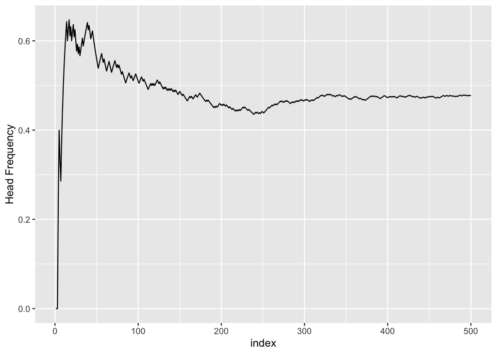

```r
library(tidyverse)
set.seed(5938)
hundreds <- toss(coin, times = 500)
head_freqs <- cumsum(hundreds == "heads") / 1:500

my_data_vis <- data.frame(index = 1:length(hundreds),
                          flips = hundreds,
                          head_freqs = head_freqs)
ggplot(my_data_vis) +
  geom_line(aes(x = index, y = head_freqs)) +
  labs(y = "Head Frequency")
```

# Overview:

So far we have written code in R that

- simulates tossing a coin one or more times.
- computed proportion of heads
- relative frequencies of heads in a series of tosses.
- produced a plot of the relative frequencies and see how, as the number of tosses increases, the frequency of heads approach 0.5

# Part III

*Object Oriented Programming*

# Motivating object structure

Take a look at these 2 experiments with coins (notice we basically did a quick “copy & paste”).

```r
# random seed
set.seed(534)

# five tosses
five <- toss(coin, times = 5)

# prop of heads in five
sum(five == "heads") / length(five)
```

```
## [1] 0.6
```

The second experiment involves tossing a coin six times and computing the proportion of heads:

```r
# six tosses
six <- toss(coin, times = 6)

# prop of heads in six
sum(six == "heads") / length(five)
```

```
## [1] 0.8
```

# Let’s make a class

To make a class, we should really be doing 3 things

1. create a **constructor** (way to create a new element of the class)
2. create **methods** to apply to the class
3. create a **validator** to check to see that an element of the class follows the desired structure

# Constructing a class (S3)

S3 objects are usually built on top of lists, or atomic vectors with attributes. You can also turn functions into S3 objects.

To make an object an instance of a class, you just take an existing base object and set the `"class"` attribute.

- You can do that during creation of the object with `structure()`,
- *or after the object has been created with `class <- ()`*.

```r
# object coin
coin1 <- structure(c("heads", "tails"),
                   class = "coin")  # better approach

# object coin
coin2 <- c("heads", "tails")
class(coin2) <- "coin"
```

You can also determine if an object inherits from a specific class using `inherits()`

```r
inherits(coin2, "coin")
```

```
## [1] TRUE
```

# Making a method: let’s flip our coin:

A coin could have a function `flip()`:

```r
flip <- function(coin, times = 1) {
  sample(coin, size = times, replace = TRUE)
}

flip(coin1)
```

```
## [1] "tails"
```

1 issue with this function is that it will “flip” anything - even things that aren’t coins:

```r
flip(c('tic', 'tac', 'toe'))
```

```
## [1] "tic"
```

# Making a method: Only flipping coins:

We could add a `stop()` condition that checks if the argument `coin` is of the right class:

```r
flip <- function(coin, times = 1) {
  if (class(coin) != "coin") {
    stop("\nflip() requires an object 'coin'")
  }
  sample(coin, size = times, replace = TRUE)
}

# ok
flip(coin1)
```

```
## [1] "heads"
```

```r
# bad coin
flip(c('tic', 'tac', 'toe'))
```

```
## Error in flip(c("tic", "tac", "toe")):
## flip() requires an object 'coin'
```

# Making a method: the OOP way

- A more formal strategy, and one that follows OOP principles, is to create a flip **method**.
  - examples of methods:

```r
# print method
print
```

```
## function (x, ...)
## UseMethod("print")
## <bytecode: 0x7f82463fb4f8>
## <environment: namespace:base>
```

```r
# plot method
plot
```

```
## function (x, y, ...)
## UseMethod("plot")
## <bytecode: 0x7f82429d8150>
## <environment: namespace:graphics>
```

- These functions (methods) are not unique functions
  - typically comprise a colelction of functions to do similar - Depending on the class of the object, a generic method will look for a specific function for that class:

```r
# methods for objects "matrix"
methods(class = "matrix")
```

```
##  [1] anyDuplicated as_tibble     as.data.frame as.raster     as.tbl_cube
##  [6] boxplot       coerce        determinant   duplicated    edit
## [11] head          initialize    isSymmetric   Math          Math2
## [16] Ops           relist        subset        summary       tail
## [21] unique
## see '?methods' for accessing help and source code
```

# Making a Method: So…, only flipping coins (the better way):

`flip` method

When implementing new methods, you begin by creating a **generic** method with the function `UseMethod()`:

```r
flip <- function(x, ...) UseMethod("flip")
```

A generic method alone is not very useful. You need to create specific cases for the generic function. In our example, we only have one class `"coin"`, we follow the naming scheme: “method_name.class_name”

```r
flip.coin <- function(x, times = 1) {
  sample(x, size = times, replace = TRUE)
}
```

Example:

```r
# good
flip(coin1)
```

```
## [1] "heads"
```

```r
# bad (no flip() method for regular vectors)
flip(c('tic', 'tac', 'toe'))
```

```
## Error in UseMethod("flip"): no applicable method for 'flip' applied to an object of class "character"
```

# Constructing a class: which option should I use?

Let’s review our class `"coin"`. The way we defined a coin object was like this:

```r
# object coin
coin1 <- c("heads", "tails")
class(coin1) <- "coin"

# bad coin
ttt <- c('tic', 'tac', 'toe')
class(ttt) <- "coin"

flip(ttt) # now flips :/
```

```
## [1] "tic"
```

# Constructing a class: create a function to wrap around element

**Constructor**

For convenience purposes, we can define a class **constructor** function to initialize a `"coin"` object:

```r
coin <- function(object = c("heads", "tails")) {
  class(object) <- "coin"
  object
}

# default coin
coin()
```

```
## [1] "heads" "tails"
## attr(,"class")
## [1] "coin"
```

```r
# another coin
coin(c("h", "t"))
```

```
## [1] "h" "t"
## attr(,"class")
## [1] "coin"
```

# Validation

- though not required, for larger objects it’s beneficial to create functions that validate the construction of an object (this is similar to testing, etc that we will talk about Monday)

```r
ttt <- coin(c("tick", "tac", "toe")) # still undesirable
```

For now, we could just write our coin as:

```r
coin <- function(object = c("heads", "tails")) {
  if (length(object) != 2) {
    stop("\n'object' must be of length 2")
  }
  class(object) <- "coin"
  object
}

standard <- coin()
standard
```

```
## [1] "heads" "tails"
## attr(,"class")
## [1] "coin"
```

```r
ttt <- coin(c("tick", "tac", "toe"))
```

```
## Error in coin(c("tick", "tac", "toe")):
## 'object' must be of length 2
```

but more will be need in the future.

# Part IV

*OOP attributes, standard methods*

# Attributes: Biased coins anyone?

The `sample` function allows for different probabilities in sampling, why not allow our coins to be biased?

```r
coin <- function(object = c("heads", "tails"), prob = c(0.5, 0.5)) {
  if (length(object) != 2) {
    stop("\n'object' must be of length 2")
  }
  attr(object, "prob") <- prob
  class(object) <- "coin"
  object
}

coin()
```

```
## [1] "heads" "tails"
## attr(,"prob")
## [1] 0.5 0.5
## attr(,"class")
## [1] "coin"
```

- similar to attributes relative to factors (they have levels)

```r
sample(c("R","D"),size = 6, replace = TRUE) %>%
  factor() %>%
  unclass %>% # unclass removes the class structure that makes print pretty
  print
```

```
## [1] 2 2 2 1 1 2
## attr(,"levels")
## [1] "D" "R"
```

# Validation 2.0: just a reminder to validate things…

```r
check_prob <- function(prob) {
  if (!is.numeric(prob)) {
    stop("\n'prob' must be a numeric vector")
  }
  if (length(prob) != 2 | !is.numeric(prob)) {
    stop("\n'prob' must be a numeric vector of length 2")
  }
  if (any(prob < 0) | any(prob > 1)) {
    stop("\n'prob' values must be between 0 and 1")
  }
  if (sum(prob) != 1) {
    stop("\nelements in 'prob' must add up to 1")
  }
  TRUE
}
```

Our updated coin class:

```r
coin <- function(object = c("heads", "tails"), prob = c(0.5, 0.5)) {
  if (length(object) != 2) {
    stop("\n'object' must be of length 2")
  }
  check_prob(prob)
  attr(object, "prob") <- prob
  class(object) <- "coin"
  object
}

coin1 <- coin()
```

# Special Classes

Some coins are special (people collect them), let’s make a special coin class:

```r
rare_coin <- function(name, year, ...){
  object <- coin(...)
  attr(object, "name") <- name
  attr(object, "year") <- year
  class(object) <- c("rare_coin", "coin")
  object
}
```

```r
my_penny <- rare_coin(name = "Lincoln penny", year =  1972)
class(my_penny)
```

```
## [1] "rare_coin" "coin"
```

```r
flip(my_penny)
```

```
## [1] "heads"
```

# Standard generics (standard methods)

We already have a `flip` method for our class, but there are lots of common functions that we apply to may objects

- Common in statistics: `summary`, `plot`, `predict`, `print`, …
- More specialized `[`, `[[`, `+`, …

  > “The greatest use of object oriented programming in R is through print methods, summary methods and plot methods. These methods allow us to have one generic function call, plot say, that dispatches on the type of its argument and calls a plotting function that is specific to the data supplied.”

  ~ R Manual (referring to the S3 system).

```r
print.coin <- function(coin){
  cat(paste0("Coin: ", coin[1], "/", coin[2], "\n"))
  prob <- attr(coin, "prob")
  cat(paste0("  Prob: ", prob[1], "/", prob[2], "\n"))
}

print.rare_coin <- function(coin){
  cat(paste0("Rare coin: ", attr(coin, "name"),
      ", ", attr(coin, "year"), "\n"))
  print.coin(coin)
}

print(coin1)
```

```
## Coin: heads/tails
##   Prob: 0.5/0.5
```

```r
print(my_penny)
```

```
## Rare coin: Lincoln penny, 1972
## Coin: heads/tails
##   Prob: 0.5/0.5
```

# Summary

- Object oriented programming (OOP) focuses on the object
- in R, there are multiple class structures, with `S3` the base and most standard, and `S4` and `R6` additionally commonly used structures
- `class()` defined and checks which class an object is (but a functionalized **constructor** is recommended)
- (S3) class specific **methods** start with a generic (defined with `UseMethod()`), and then have specific methods per class `function_name.class_name`
  - there are also standard generic functions which need not be reinitialized.
- Best practice is to create **validators** to check if the assumptions of the class are met